# README.Rmd

# Preguntas

## a. Examine the portion of the script you see below. In your own words what does this section do and why does it work?

This section first sets the codes to meassure vowel duration (vonset, voffset) Then the script sets the code to get of F1 and F2 at five equidistant temporal location. The five last lines are important since meassure different vowel distance in a space not only the centroid.

vonset = Get starting point: 2, 2: the point when the vowel starts

voffset = Get end point: 2, 2: the points when the vowel ends

durationV = voffset - vonset: vowel duration is the offset of the vowel less the onset of the vowel

per20 = vonset + (durationV * 0.20): is the 20% of the total vowel duration

per35 = vonset + (durationV * 0.35): is the 35% of the total vowel duration

per50 = vonset + (durationV * 0.50): is the 50% of the total vowel duration

per65 = vonset + (durationV * 0.65): is the 65% of the total vowel duration

per80 = vonset + (durationV * 0.80): is the 80% of the total vowel duration

## b. In a few short sentences describe the general outline of the script, what the purpose is, and how it acheives this purpose (hint: focus on the section dividers and the comments)

The script has three sections:

b.1 set up output file: praat sets in which folder the data will be storage, then it names the files and the program creates the columns for the dataframe

b.2 set up the loop: the program looks for the file in my desktop (stim folder) an then it creates the variables with the wav file and the textgrid and finaly the program adds a column with my id

b.3 run the loop: the program states all the necessary conditions from interval 1 at the end to run the loop. Then the program sets the variables, then the five different vowel distances, the spectral centroide and trajectory lenght. Finally the program prints the codes and it removes object from praat.

## c. In a few short sentences describe how the segmenting procedure you used this week differs from that used in pa_2. What are the advantages and disadvantages?

The current segmentation was longer than the previous one and it contains three tiers, unlike the previous one that it had only one. The advantage of PA3 segmentation is that I can get more information indicating the onset and the offset of the vowel and also the point tear provides useful language information to manipulate the data in R. The disvantage is the difficulty to get accurate meassurement in order to run the script.

cargar base de datos

```r
library(tidyverse)
df1 = read_csv("data/vowel_data.csv")
```

## Descriptive statistics

```r
df1 %>%
    summarise(media_f1 = mean(f1_cent), sd_f1 = sd(f1_cent), media_f2 = mean(f2_cent), sd_f2 = sd(f2_cent),  meadia_tl = mean(tl), sd_tl = sd(tl))
```

```
## # A tibble: 1 x 6
##   media_f1 sd_f1 media_f2 sd_f2 meadia_tl sd_tl
##      <dbl> <dbl>    <dbl> <dbl>     <dbl> <dbl>
## 1     581.  278.    1547.  498.     1144. 1119.
```

## Plot 1 trajectory length as a function of vowel and language

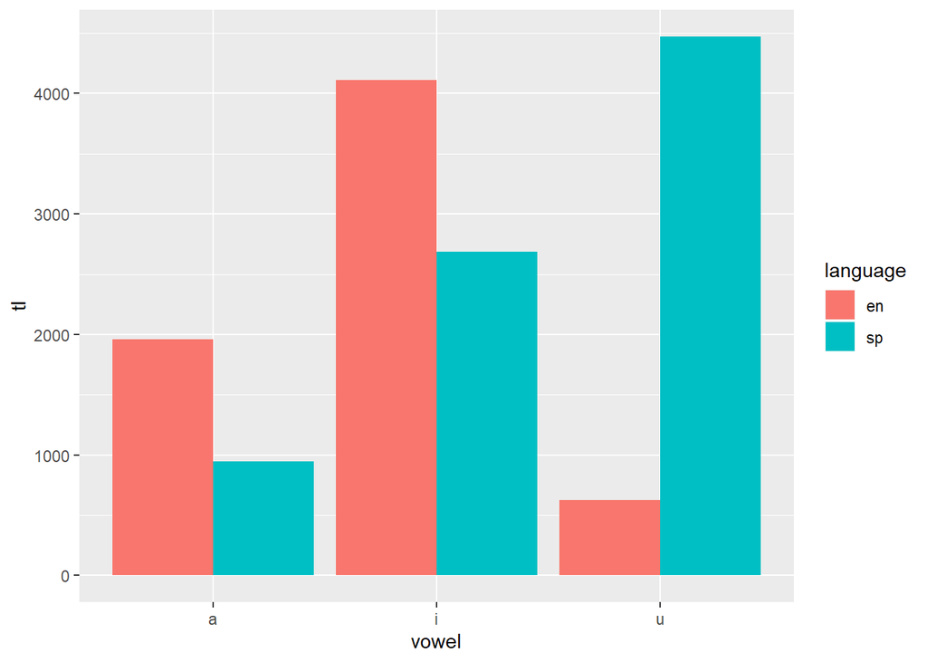

```r
  ggplot(df1, aes(fill= language, y=tl, x=vowel)) +
  geom_bar(position="dodge", stat="identity")
```

## Plot 2 F1 as a function of vowel and language

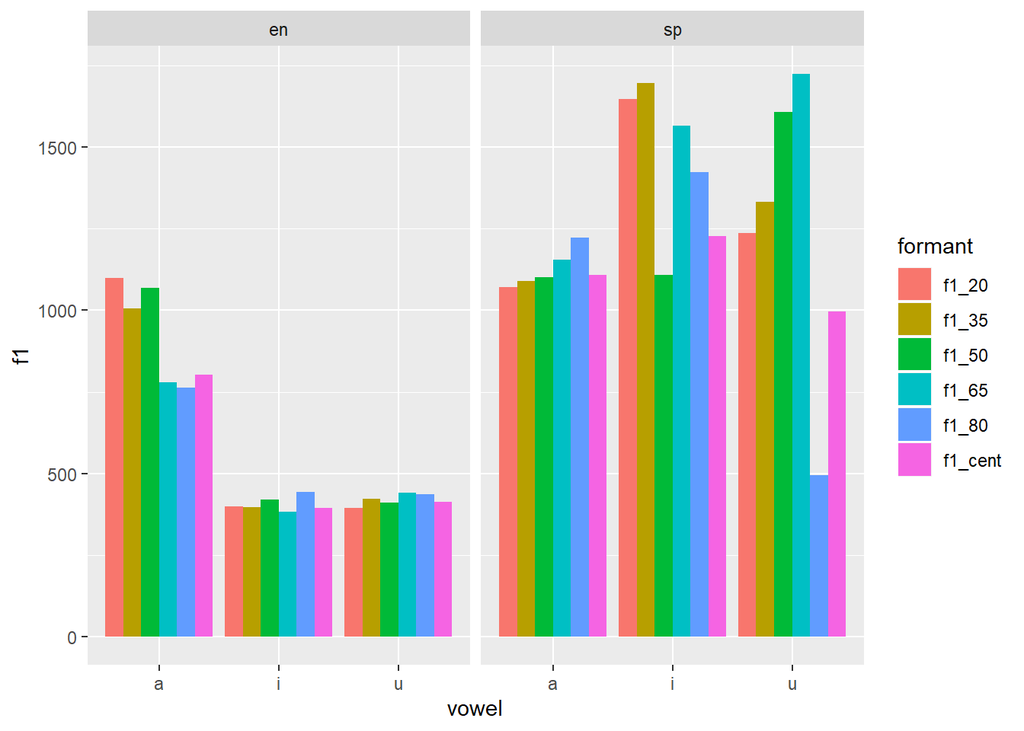

```r
df1 %>%
  select(vowel, language, f1_cent, f1_20, f1_35, f1_50, f1_65, f1_80 ) %>%
  gather("formant", "f1" , - vowel, - language) %>%
  ggplot(aes(fill= formant, y=f1, x=vowel)) +
    geom_bar(position="dodge", stat="identity") +
    facet_grid(. ~ language)
```

## Plot 3 F2 as a function of vowel and language

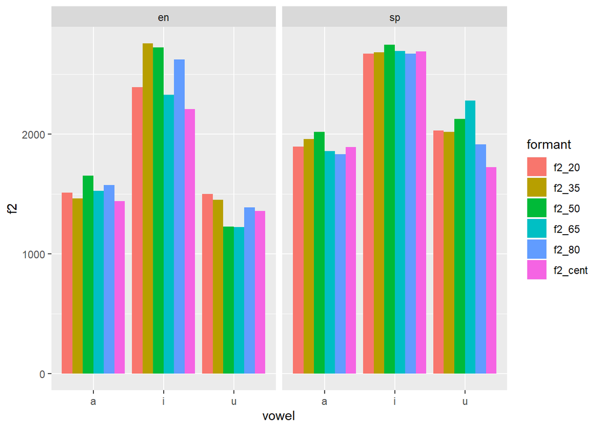

```r
df1 %>%
  select(vowel, language, f2_cent, f2_20, f2_35, f2_50, f2_65, f2_80 ) %>%
  gather("formant", "f2" , - vowel, - language) %>%
  ggplot(aes(fill= formant, y=f2, x=vowel)) +
    geom_bar(position="dodge", stat="identity") +
    facet_grid(. ~ language)
```